# Bellabeat Fitness Tracker Analysis

Jessica Wales

2023-10-28

# Trends in Fitness Tracker Technology

Fitness trackers allow companies to collect data that give us incredible insights into how wearable makers can provide valuable products for their consumers. In this case study, I’ve examined data collected from Fitbit users in order to see how fitness tracker users use their fitness trackers to inform themselves and make better decisions for their health. I have gathered some leading trends in smart device usage in order to inform how Bellabeat about some marketing strategies.

# Business Objective

1. What are some trends in smart device usage?
2. How could these trends apply to Bellabeat customers?
3. How could these trends help influence Bellabeat marketing strategy?

# Data Source

The data comes from data sets found at https://www.kaggle.com/datasets/arashnic/fitbit and are in the public domain.

# Scatter Plot of Total Steps vs. Calories

Here we see a plot of total steps compared to calories burned. Generally the more steps a wearer took, the more calories they burned and the higher the number of “active minutes” they spent.

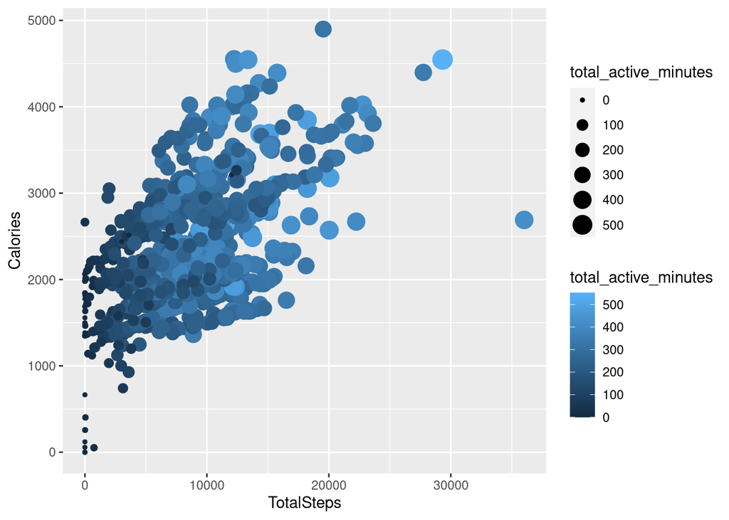

The following plots break down the total active minutes into “lightly,” “fairly,” and “very active minutes. We can see that the majority of the”active minutes” participants spent walking were considered “lightly active minutes.”

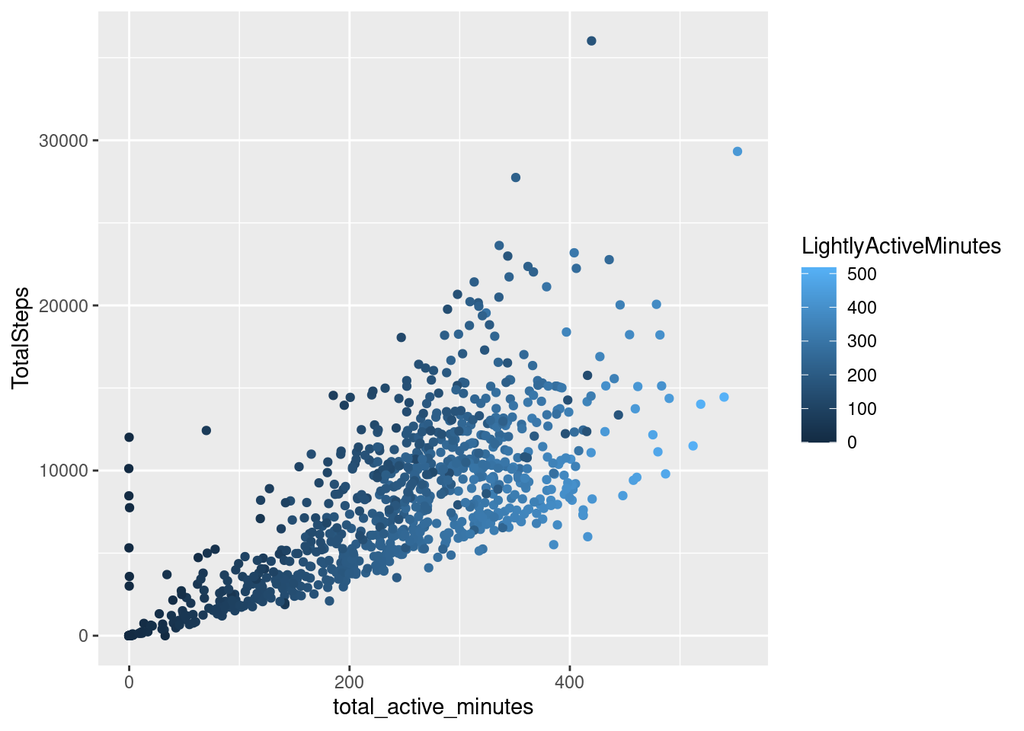

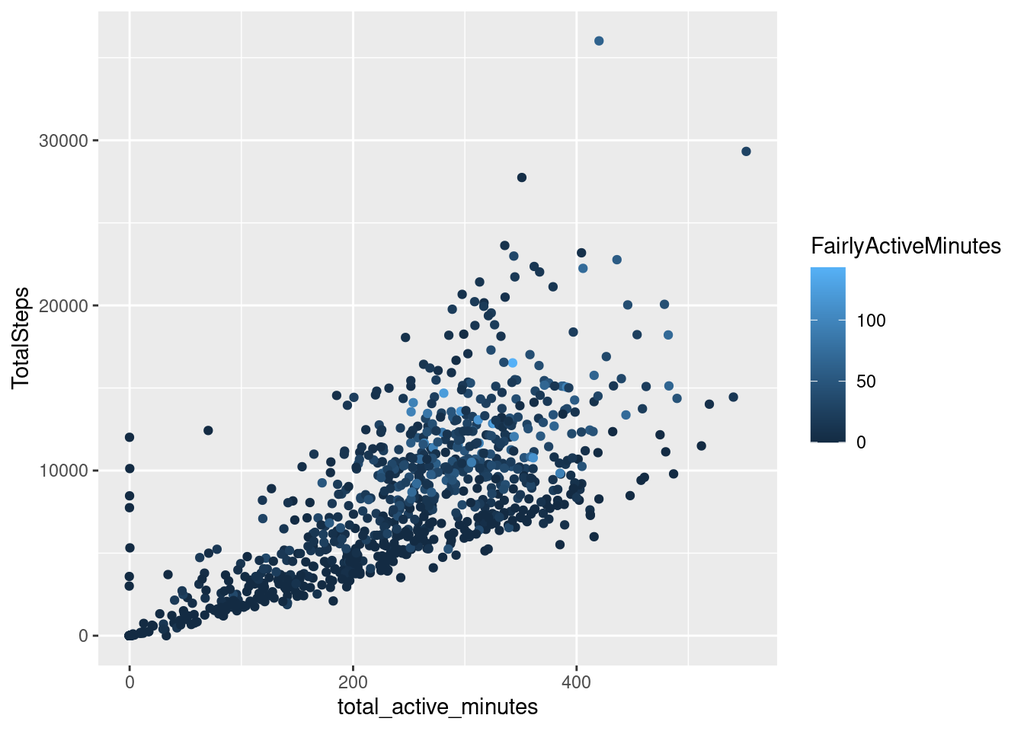

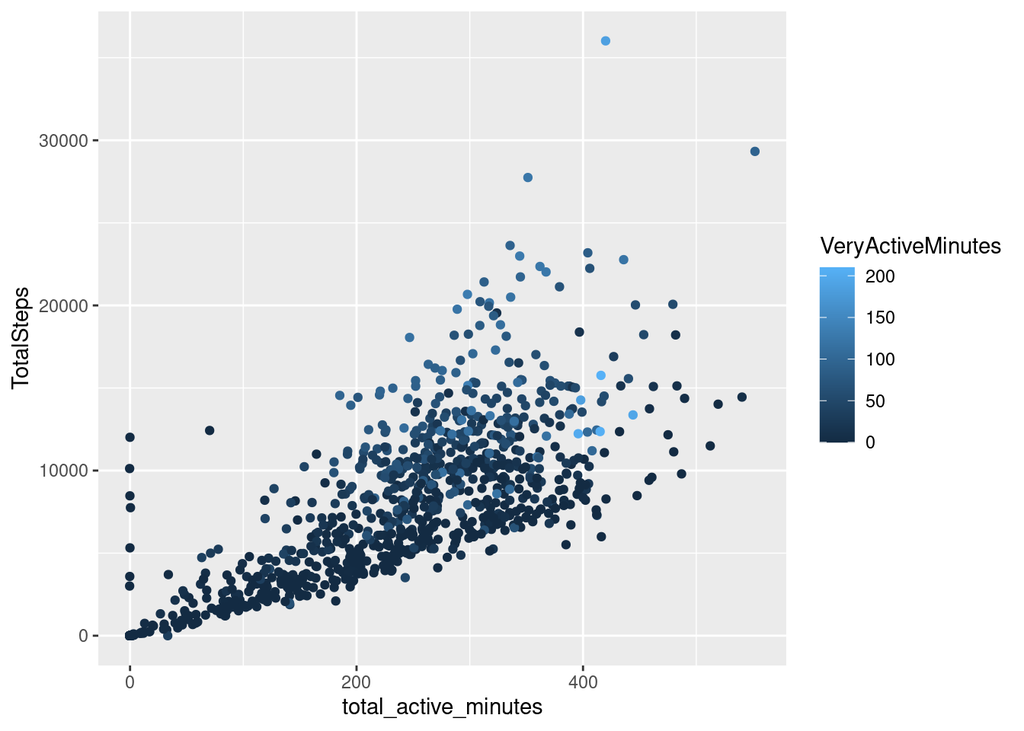

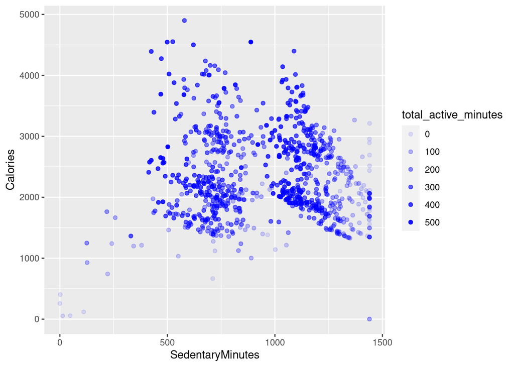

We also see a correlation of the more time spent in bed, the more minutes the participants slept.

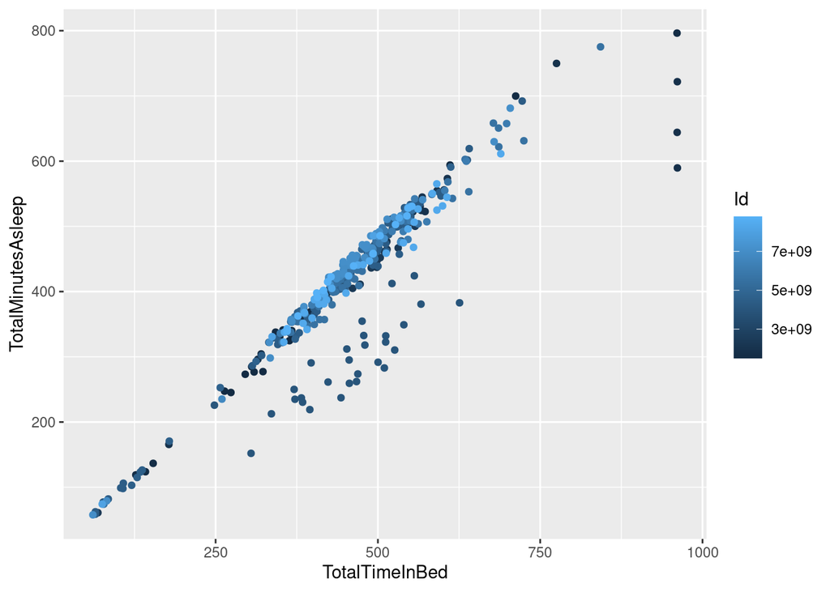

# Average Minutes Spent at Different Activity Levels

In the pie chart below, we can see the average number of minutes Fitbit users spent each day at different activity levels. These categories include Sleep, Sedentary Minutes, Lightly Active Minutes, Fairly Active Minutes, and Very Active Minutes. The average user spends about one-sixth of their day actively moving, while the rest of the time is spent either sedentary or asleep.

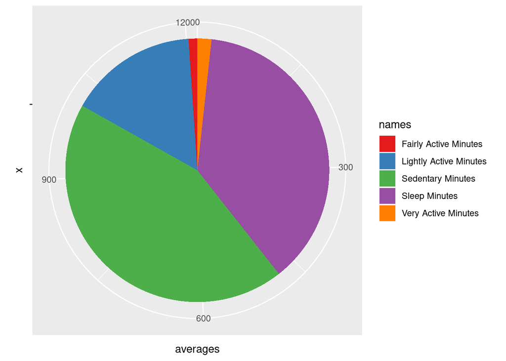

# Conclusion

From my analysis, we can see that fitness tracker users are somewhat active, but could be encouraged to be even more active to improve their health and reach fitness goals. One way this could be achieved is to allow the fitness tracker and/or corresponding app to prompt the user to be more active when they have spent a certain amount of time being sedentary. It could also prompt the user to sleep and wake at certain times for optimum sleep health.